# R Notebook

```r
library(tidyverse)
```

```r
house_data <- read_csv("data/kc_house_data.csv")
```

```r
house_data
```

| id | date | price | bedrooms | bathrooms | sqft_living | sqft_lot | floors | waterfront | view | condition | grade | sqft_above | sqft_basement | yr_built | yr_renovated | zipcode | lat | long | sqft_living15 | sqft_lot15 |
| --- | --- | --- | --- | --- | --- | --- | --- | --- | --- | --- | --- | --- | --- | --- | --- | --- | --- | --- | --- | --- |
| 7129300520 | 2014-10-13 | 221900 | 3 | 1.00 | 1180 | 5650 | 1.0 | 0 | 0 | 3 | 7 | 1180 | 0 | 1955 | 0 | 98178 | 47.5112 | -122.257 | 1340 | 5650 |
| 6414100192 | 2014-12-09 | 538000 | 3 | 2.25 | 2570 | 7242 | 2.0 | 0 | 0 | 3 | 7 | 2170 | 400 | 1951 | 1991 | 98125 | 47.7210 | -122.319 | 1690 | 7639 |
| 5631500400 | 2015-02-25 | 180000 | 2 | 1.00 | 770 | 10000 | 1.0 | 0 | 0 | 3 | 6 | 770 | 0 | 1933 | 0 | 98028 | 47.7379 | -122.233 | 2720 | 8062 |
| 2487200875 | 2014-12-09 | 604000 | 4 | 3.00 | 1960 | 5000 | 1.0 | 0 | 0 | 5 | 7 | 1050 | 910 | 1965 | 0 | 98136 | 47.5208 | -122.393 | 1360 | 5000 |
| 1954400510 | 2015-02-18 | 510000 | 3 | 2.00 | 1680 | 8080 | 1.0 | 0 | 0 | 3 | 8 | 1680 | 0 | 1987 | 0 | 98074 | 47.6168 | -122.045 | 1800 | 7503 |
| 7237550310 | 2014-05-12 | 1225000 | 4 | 4.50 | 5420 | 101930 | 1.0 | 0 | 0 | 3 | 11 | 3890 | 1530 | 2001 | 0 | 98053 | 47.6561 | -122.005 | 4760 | 101930 |
| 1321400060 | 2014-06-27 | 257500 | 3 | 2.25 | 1715 | 6819 | 2.0 | 0 | 0 | 3 | 7 | 1715 | 0 | 1995 | 0 | 98003 | 47.3097 | -122.327 | 2238 | 6819 |
| 2008000270 | 2015-01-15 | 291850 | 3 | 1.50 | 1060 | 9711 | 1.0 | 0 | 0 | 3 | 7 | 1060 | 0 | 1963 | 0 | 98198 | 47.4095 | -122.315 | 1650 | 9711 |
| 2414600126 | 2015-04-15 | 229500 | 3 | 1.00 | 1780 | 7470 | 1.0 | 0 | 0 | 3 | 7 | 1050 | 730 | 1960 | 0 | 98146 | 47.5123 | -122.337 | 1780 | 8113 |
| 3793500160 | 2015-03-12 | 323000 | 3 | 2.50 | 1890 | 6560 | 2.0 | 0 | 0 | 3 | 7 | 1890 | 0 | 2003 | 0 | 98038 | 47.3684 | -122.031 | 2390 | 7570 |

[output cut: 990 more lines]

Tidy up the data ready for regression:

You might like to think about removing some or all of date, id, sqft_living15, sqft_lot15 and zipcode (lat and long provide a better measure of location in any event).

```r
house_data_tidy <- house_data %>%
  select(-c("date", "id", "sqft_living15", "sqft_lot15", "zipcode"))

house_data_tidy
```

| price | bedrooms | bathrooms | sqft_living | sqft_lot | floors | waterfront | view | condition | grade | sqft_above | sqft_basement | yr_built | yr_renovated | lat | long |
| --- | --- | --- | --- | --- | --- | --- | --- | --- | --- | --- | --- | --- | --- | --- | --- |
| 221900 | 3 | 1.00 | 1180 | 5650 | 1.0 | 0 | 0 | 3 | 7 | 1180 | 0 | 1955 | 0 | 47.5112 | -122.257 |
| 538000 | 3 | 2.25 | 2570 | 7242 | 2.0 | 0 | 0 | 3 | 7 | 2170 | 400 | 1951 | 1991 | 47.7210 | -122.319 |
| 180000 | 2 | 1.00 | 770 | 10000 | 1.0 | 0 | 0 | 3 | 6 | 770 | 0 | 1933 | 0 | 47.7379 | -122.233 |
| 604000 | 4 | 3.00 | 1960 | 5000 | 1.0 | 0 | 0 | 5 | 7 | 1050 | 910 | 1965 | 0 | 47.5208 | -122.393 |
| 510000 | 3 | 2.00 | 1680 | 8080 | 1.0 | 0 | 0 | 3 | 8 | 1680 | 0 | 1987 | 0 | 47.6168 | -122.045 |
| 1225000 | 4 | 4.50 | 5420 | 101930 | 1.0 | 0 | 0 | 3 | 11 | 3890 | 1530 | 2001 | 0 | 47.6561 | -122.005 |
| 257500 | 3 | 2.25 | 1715 | 6819 | 2.0 | 0 | 0 | 3 | 7 | 1715 | 0 | 1995 | 0 | 47.3097 | -122.327 |
| 291850 | 3 | 1.50 | 1060 | 9711 | 1.0 | 0 | 0 | 3 | 7 | 1060 | 0 | 1963 | 0 | 47.4095 | -122.315 |
| 229500 | 3 | 1.00 | 1780 | 7470 | 1.0 | 0 | 0 | 3 | 7 | 1050 | 730 | 1960 | 0 | 47.5123 | -122.337 |
| 323000 | 3 | 2.50 | 1890 | 6560 | 2.0 | 0 | 0 | 3 | 7 | 1890 | 0 | 2003 | 0 | 47.3684 | -122.031 |

[output cut: 990 more lines]

Have a think about how to treat waterfront. Should we convert its type?

We converted yr_renovated into a renovated logical variable, indicating whether the property had ever been renovated. You may wish to do the same.

Have a think about how to treat condition and grade? Are they interval or categorical ordinal data types?

Check for aliased variables using the alias() function (this takes in a formula object and a data set). [Hint - formula price ~ . says ‘price varying with all predictors’, this is a suitable input to alias()]. Remove variables that lead to an alias. Check the ‘Elements of multiple regression’ lesson for a dropdown containing further information on finding aliased variables in a dataset.

```r
library(modelr)
```

```r
alias(lm(price~ ., data = house_data_tidy))
```

```
Model :
price ~ bedrooms + bathrooms + sqft_living + sqft_lot + floors +
    waterfront + view + condition + grade + sqft_above + sqft_basement +
    yr_built + yr_renovated + lat + long

Complete :
              (Intercept) bedrooms bathrooms sqft_living sqft_lot floors waterfront view condition
sqft_basement  0           0        0         1           0        0      0          0    0
              grade sqft_above yr_built yr_renovated lat long
sqft_basement  0    -1          0        0            0   0
```

```r
house_price_tidy <- house_data_tidy %>%
  select(-c("sqft_living", "sqft_above"))
```

Systematically build a regression model containing up to four main effects (remember, a main effect is just a single predictor with coefficient), testing the regression diagnostics as you go

splitting datasets into numeric and non-numeric columns might help ggpairs() run in manageable time, although you will need to add either a price or resid column to the non-numeric dataframe in order to see its correlations with the non-numeric predictors.

```r
library(GGally)
```

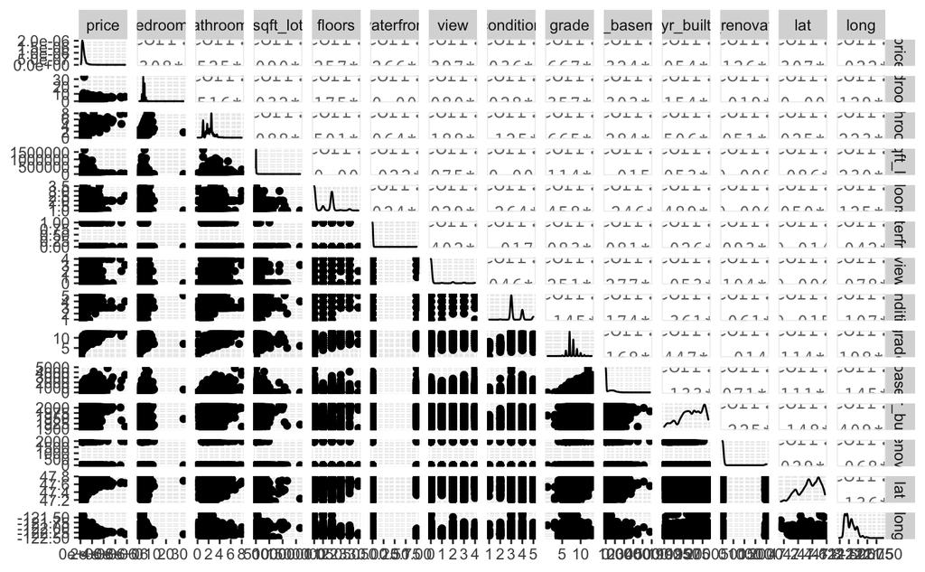

```r
houses_tidy_numeric <- house_price_tidy %>%
  select_if(is.numeric)

houses_tidy_nonnumeric <- house_price_tidy %>%
  select_if(function(x) !is.numeric(x))

houses_tidy_nonnumeric$price <- house_price_tidy$price

ggpairs(houses_tidy_numeric)
```

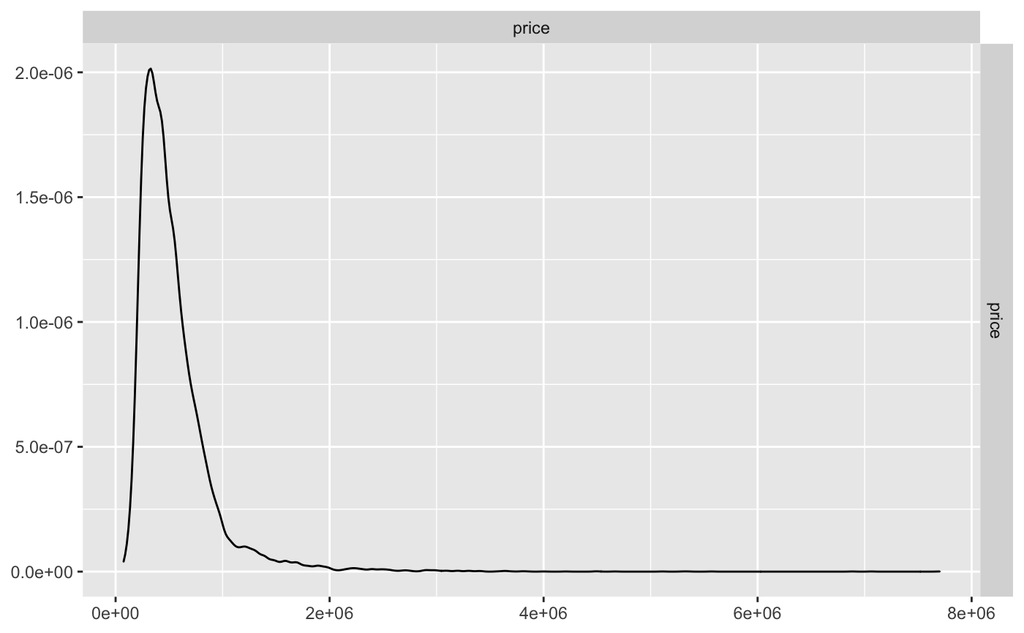

```r
ggpairs(houses_tidy_nonnumeric)
```

```r
mod1a <- lm(price ~ grade, data = houses_tidy_numeric)

mod1a
```

```
Call:
lm(formula = price ~ grade, data = houses_tidy_numeric)

Coefficients:
(Intercept)        grade
   -1056045       208458
```

```r
summary(mod1a)
```

```
Call:
lm(formula = price ~ grade, data = houses_tidy_numeric)

Residuals:
    Min      1Q  Median      3Q     Max
-816988 -151958  -36158   97842 6046097

Coefficients:
            Estimate Std. Error t value Pr(>|t|)
(Intercept) -1056045      12256  -86.17   <2e-16 ***
grade         208458       1582  131.76   <2e-16 ***
---
Signif. codes:  0 ‘***’ 0.001 ‘**’ 0.01 ‘*’ 0.05 ‘.’ 0.1 ‘ ’ 1

Residual standard error: 273400 on 21611 degrees of freedom
Multiple R-squared:  0.4455,    Adjusted R-squared:  0.4454
F-statistic: 1.736e+04 on 1 and 21611 DF,  p-value: < 2.2e-16
```

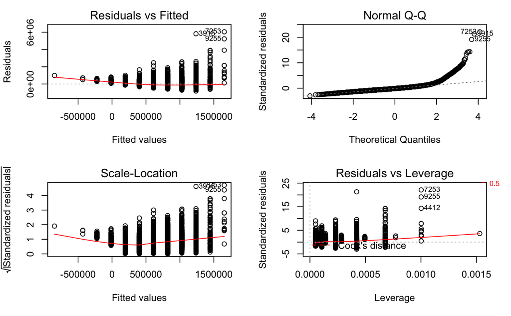

```r
par(mfrow = c(2,2))
plot(mod1a)
```

```r
mod2a <- lm(price ~ condition, data = house_data_tidy)

mod2a
```

```
Call:
lm(formula = price ~ condition, data = house_data_tidy)

Coefficients:
(Intercept)    condition
     470147        20514
```

```r
summary(mod2a)
```

```
Call:
lm(formula = price ~ condition, data = house_data_tidy)

Residuals:
    Min      1Q  Median      3Q     Max
-463203 -217203  -87203  101797 7147797

Coefficients:
            Estimate Std. Error t value Pr(>|t|)
(Intercept)   470147      13312  35.318  < 2e-16 ***
condition      20514       3835   5.349 8.94e-08 ***
---
Signif. codes:  0 ‘***’ 0.001 ‘**’ 0.01 ‘*’ 0.05 ‘.’ 0.1 ‘ ’ 1

Residual standard error: 366900 on 21611 degrees of freedom
Multiple R-squared:  0.001322,  Adjusted R-squared:  0.001276
F-statistic: 28.61 on 1 and 21611 DF,  p-value: 8.936e-08
```

```r
house_remianing_resid <- houses_tidy_numeric %>%
  add_residuals(mod1a) %>%
  select(-c("price", "grade"))

house_remianing_resid %>%
  ggpairs(aes(colour = condition, alpha = 0.5))
```

```
Error in ggally_statistic(data = data, mapping = mapping, na.rm = na.rm,  :
  `mapping` color column must be categorical, not numeric
```

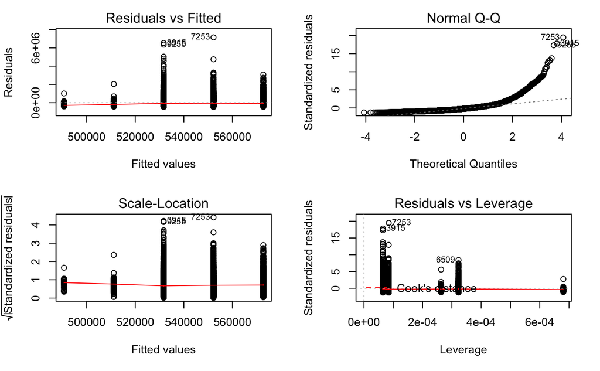

```r
par(mfrow = c(2,2))
plot(mod2a)
```

```r
anova(mod1a, mod2a)
```

```
Analysis of Variance Table

Model 1: price ~ grade
Model 2: price ~ condition
  Res.Df        RSS Df   Sum of Sq F Pr(>F)
1  21611 1.6153e+15
2  21611 2.9091e+15  0 -1.2938e+15
```

```r
mod1b <- lm(price ~ long, data = houses_tidy_numeric)

mod1b
```

```
Call:
lm(formula = price ~ long, data = houses_tidy_numeric)

Coefficients:
(Intercept)         long
    7430229        56378
```

```r
summary(mod1b)
```

```
Call:
lm(formula = price ~ long, data = houses_tidy_numeric)

Residuals:
    Min      1Q  Median      3Q     Max
-482447 -218209  -88758  102766 7166063

Coefficients:
            Estimate Std. Error t value Pr(>|t|)
(Intercept)  7430229    2166748   3.429 0.000606 ***
long           56378      17729   3.180 0.001475 **
---
Signif. codes:  0 ‘***’ 0.001 ‘**’ 0.01 ‘*’ 0.05 ‘.’ 0.1 ‘ ’ 1

Residual standard error: 367000 on 21611 degrees of freedom
Multiple R-squared:  0.0004677, Adjusted R-squared:  0.0004214
F-statistic: 10.11 on 1 and 21611 DF,  p-value: 0.001475
```